# Наш первый отчёт

Aleksei Zamalutdinov

2023-01-16

# R Markdown

**Это R** Markdown документ. Markdown - это простой язык разметки для создания *HTML*, PDF, и MS Word документов. Подробнее об использовании R Markdown http://rmarkdown.rstudio.com.

Когда вы нажимаете кнопку **Knit** будет создан документ, включающий как текстовые разделы так и результат исполнения чанков с кодом внутри документа.

Здесь мы можем проводить наши анлизы как обычно, но здесь их структурировать проще

## EDA (Exploratory data analysis)

Мы научились считать разные статистики, корреляции, делать тесты и проверять гипотезы. Но до сих пор мы работали с более или менее подготовленными данными. Здесь мы обсудим как работать с новыми сырыми данными.

Прежде всего мы должны взглянуть на наши данные, определить какие переменные у нас, сколько наблюдений, как взаимосвязаны переменные, есть ли пропуски и выбросы и тд и тп. Всё это называется EDA или разведочный анализ.

Основные цели:

1. Понимание структуры данных (сколько, какой тип, дубликаты, пропущенные и тп)
2. Выявление аномалий и выбросов
3. Определение связей между переменными
4. Подготовка данных для дальнейшего анализа

Подробнее можно почитать тут https://habr.com/ru/companies/otus/articles/752434/

Мы же перейдём к примеру. Поработаем с датасетом о ценах на страховку

```r
library(dplyr)
```

```r
library(ggplot2)
library(knitr)
main_dir <- dirname(rstudioapi::getSourceEditorContext()$path)
setwd(main_dir)
```

### Обзор данных

```r
insurance <- read.csv("insurance.csv", sep=";")
str(insurance)
```

```
## 'data.frame':    1338 obs. of  7 variables:
##  $ age     : int  19 18 28 33 32 31 46 37 37 60 ...
##  $ sex     : chr  "female" "male" "male" "male" ...
##  $ bmi     : num  27.9 33.8 33 22.7 28.9 ...
##  $ children: chr  "0" "1" "3" "0" ...
##  $ smoker  : chr  "yes" "no" "no" "no" ...
##  $ region  : chr  "southwest" "southeast" "southeast" "northwest" ...
##  $ charges : num  16885 1726 4449 21984 3867 ...
```

Какие переменные у нас есть:

age: возраст

sex: пол

bmi: индекс массы тела, рассчитывается как (kg / рост в метрах ^ 2), в идеале от 18.5 до 24.9

children: количество детей

smoker: курение

region: регион США

charges: цена

Начнём с проверки наших данных. Что вы думаете?

На мой взгляд странно, что children являются типом character. Используем ещё одну базовую функцию для беглого взгляда на данные

```r
summary(insurance)
```

```
##       age             sex                 bmi           children
##  Min.   : 18.00   Length:1338        Min.   : 15.96   Length:1338
##  1st Qu.: 27.00   Class :character   1st Qu.: 26.25   Class :character
##  Median : 39.00   Mode  :character   Median : 30.40   Mode  :character
##  Mean   : 39.37                      Mean   : 31.09
##  3rd Qu.: 51.00                      3rd Qu.: 34.70
##  Max.   :222.00                      Max.   :341.00
##  NA's   :2                           NA's   :7
##     smoker             region             charges
##  Length:1338        Length:1338        Min.   : 1122
##  Class :character   Class :character   1st Qu.: 4724
##  Mode  :character   Mode  :character   Median : 9370
##                                        Mean   :13261
##                                        3rd Qu.:16640
##                                        Max.   :63770
##
```

Видим, что числовые колонки тоже не без проблем.

### Работа с пропущенными значениями

Начнём с того, что проверим сколько у нас пропущенных значений. В наших данных 9 пропущенных значений

Есть несколько вариантов того, что мы можем сделать с ними:

1. Просто выкинуть эти наблюдения
2. Заполнить средним значением (ну или как-то более сложно)
3. Заполнить нулями

```r
sum(is.na(insurance[is.na(insurance)] <- 0))
```

```
## [1] 0
```

4. Оставить как есть

У нас довольно много наблюдений, поэтому лучше выкинуть пропущенное. Можно сделать это с помощью dplyr

```r
#insurance_without_na <-
#summary(insurance_without_na)
```

```r
insurance_without_na <- na.omit(insurance)
summary(insurance_without_na)
```

```
##       age             sex                 bmi           children
##  Min.   :  0.00   Length:1338        Min.   :  0.00   Length:1338
##  1st Qu.: 27.00   Class :character   1st Qu.: 26.18   Class :character
##  Median : 39.00   Mode  :character   Median : 30.30   Mode  :character
##  Mean   : 39.31                      Mean   : 30.93
##  3rd Qu.: 51.00                      3rd Qu.: 34.66
##  Max.   :222.00                      Max.   :341.00
##     smoker             region             charges
##  Length:1338        Length:1338        Min.   : 1122
##  Class :character   Class :character   1st Qu.: 4724
##  Mode  :character   Mode  :character   Median : 9370
##                                        Mean   :13261
##                                        3rd Qu.:16640
##                                        Max.   :63770
```

### Замена опечаток

Посмотрим на колонку children. Сначала взглянем на все уникальные значения из неё

```r
sort(unique(insurance_without_na$children))
```

```
##  [1] "0"     "1"     "2"     "22"    "3"     "33"    "4"     "5"     "One"
## [10] "Three" "Two"   "Zero"
```

Сразу видим два типа проблем: текстовые значения и возможные выбросы. Выбросы похоже на случайное нажатие клавиши дважды, но для надёжности лучше выбросим их. Уберем снова используя dplyr

```r
insurance_without_na_child <- filter(insurance_without_na, children!="22" & children!="33")
str(filter(insurance_without_na, !(children %in% c("22","33"))))
```

```
## 'data.frame':    1336 obs. of  7 variables:
##  $ age     : num  19 18 28 33 32 31 46 37 60 25 ...
##  $ sex     : chr  "female" "male" "male" "male" ...
##  $ bmi     : num  27.9 33.8 33 22.7 28.9 ...
##  $ children: chr  "0" "1" "3" "0" ...
##  $ smoker  : chr  "yes" "no" "no" "no" ...
##  $ region  : chr  "southwest" "southeast" "southeast" "northwest" ...
##  $ charges : num  16885 1726 4449 21984 3867 ...
```

Вторую проблему можно решить конвертацией текста в его значение. Используем case_when для этого

```r
insurance_without_na_child_fix <- insurance_without_na_child %>% mutate(children = case_when(
                                         children == "Zero" ~ 0,
                                         children == "One" ~ 1,
                                         children == "Two" ~ 2,
                                         children == "Three" ~ 3,
                                         TRUE ~ as.double(children)))
summary(insurance_without_na_child_fix)
```

```
##       age             sex                 bmi            children
##  Min.   :  0.00   Length:1336        Min.   :  0.00   Min.   :0.000
##  1st Qu.: 26.75   Class :character   1st Qu.: 26.20   1st Qu.:0.000
##  Median : 39.00   Mode  :character   Median : 30.33   Median :1.000
##  Mean   : 39.32                      Mean   : 30.93   Mean   :1.093
##  3rd Qu.: 51.00                      3rd Qu.: 34.68   3rd Qu.:2.000
##  Max.   :222.00                      Max.   :341.00   Max.   :5.000
##     smoker             region             charges
##  Length:1336        Length:1336        Min.   : 1122
##  Class :character   Class :character   1st Qu.: 4734
##  Mode  :character   Mode  :character   Median : 9382
##                                        Mean   :13273
##                                        3rd Qu.:16687
##                                        Max.   :63770
```

Стало лучше)

### Категориальные величины

С категориальными величинами удобнее работать, когда R знает что они такие) Конвертируем их в фактор

```r
insurance_without_na_child_fix$sex <- as.factor(insurance_without_na_child_fix$sex)
insurance_without_na_child_fix$smoker <- as.factor(insurance_without_na_child_fix$smoker)
insurance_without_na_child_fix$region <- as.factor(insurance_without_na_child_fix$region)
summary(insurance_without_na_child_fix)
```

```
##       age             sex           bmi            children       smoker
##  Min.   :  0.00   female:660   Min.   :  0.00   Min.   :0.000   False:   1
##  1st Qu.: 26.75   Female:  1   1st Qu.: 26.20   1st Qu.:0.000   no   :1059
##  Median : 39.00   male  :674   Median : 30.33   Median :1.000   No   :   2
##  Mean   : 39.32   Male  :  1   Mean   : 30.93   Mean   :1.093   True :   1
##  3rd Qu.: 51.00                3rd Qu.: 34.68   3rd Qu.:2.000   yes  : 271
##  Max.   :222.00                Max.   :341.00   Max.   :5.000   Yes  :   2
##
##        region       charges
##  southeast:363   Min.   : 1122
##  northeast:324   1st Qu.: 4734
##  southwest:323   Median : 9382
##  northwest:322   Mean   :13273
##  norhwest :  1   3rd Qu.:16687
##  nothwest :  1   Max.   :63770
##  (Other)  :  2
```

Теперь мы видим распределение между уровнями наших категориальных переменных. В некоторых случаях значения те же, отличаются только заглавной буквой. Решим проблему с помощью casefold()

```r
insurance_without_na_child_fix_s <- insurance_without_na_child_fix %>% mutate(sex=casefold(sex, upper = F))
insurance_without_na_child_fix_s$sex <- as.factor(insurance_without_na_child_fix_s$sex)
summary(insurance_without_na_child_fix_s)
```

```
##       age             sex           bmi            children       smoker
##  Min.   :  0.00   female:661   Min.   :  0.00   Min.   :0.000   False:   1
##  1st Qu.: 26.75   male  :675   1st Qu.: 26.20   1st Qu.:0.000   no   :1059
##  Median : 39.00                Median : 30.33   Median :1.000   No   :   2
##  Mean   : 39.32                Mean   : 30.93   Mean   :1.093   True :   1
##  3rd Qu.: 51.00                3rd Qu.: 34.68   3rd Qu.:2.000   yes  : 271
##  Max.   :222.00                Max.   :341.00   Max.   :5.000   Yes  :   2
##
##        region       charges
##  southeast:363   Min.   : 1122
##  northeast:324   1st Qu.: 4734
##  southwest:323   Median : 9382
##  northwest:322   Mean   :13273
##  norhwest :  1   3rd Qu.:16687
##  nothwest :  1   Max.   :63770
##  (Other)  :  2
```

Отлично, сделаем то же самое с колонкой smoker

```r
insurance_without_na_child_fix_s_s <- insurance_without_na_child_fix_s %>% mutate(smoker=casefold(smoker, upper = F))
insurance_without_na_child_fix_s_s$smoker <- as.factor(insurance_without_na_child_fix_s_s$smoker)
summary(insurance_without_na_child_fix_s_s)
```

```
##       age             sex           bmi            children       smoker
##  Min.   :  0.00   female:661   Min.   :  0.00   Min.   :0.000   false:   1
##  1st Qu.: 26.75   male  :675   1st Qu.: 26.20   1st Qu.:0.000   no   :1061
##  Median : 39.00                Median : 30.33   Median :1.000   true :   1
##  Mean   : 39.32                Mean   : 30.93   Mean   :1.093   yes  : 273
##  3rd Qu.: 51.00                3rd Qu.: 34.68   3rd Qu.:2.000
##  Max.   :222.00                Max.   :341.00   Max.   :5.000
##
##        region       charges
##  southeast:363   Min.   : 1122
##  northeast:324   1st Qu.: 4734
##  southwest:323   Median : 9382
##  northwest:322   Mean   :13273
##  norhwest :  1   3rd Qu.:16687
##  nothwest :  1   Max.   :63770
##  (Other)  :  2
```

Остались ещё небольшие правки. Сделаем их с mutate и if_else()

```r
insurance_without_na_child_fix_s_s <-insurance_without_na_child_fix_s_s %>%
  mutate(smoker = if_else(smoker=="false","no",as.character(smoker))) %>%
  mutate(smoker = if_else(smoker=="true","yes",as.character(smoker)))
insurance_without_na_child_fix_s_s$smoker <- as.factor(insurance_without_na_child_fix_s_s$smoker)
summary(insurance_without_na_child_fix_s_s)
```

```
##       age             sex           bmi            children     smoker
##  Min.   :  0.00   female:661   Min.   :  0.00   Min.   :0.000   no :1062
##  1st Qu.: 26.75   male  :675   1st Qu.: 26.20   1st Qu.:0.000   yes: 274
##  Median : 39.00                Median : 30.33   Median :1.000
##  Mean   : 39.32                Mean   : 30.93   Mean   :1.093
##  3rd Qu.: 51.00                3rd Qu.: 34.68   3rd Qu.:2.000
##  Max.   :222.00                Max.   :341.00   Max.   :5.000
##
##        region       charges
##  southeast:363   Min.   : 1122
##  northeast:324   1st Qu.: 4734
##  southwest:323   Median : 9382
##  northwest:322   Mean   :13273
##  norhwest :  1   3rd Qu.:16687
##  nothwest :  1   Max.   :63770
##  (Other)  :  2
```

Последняя проблема с колонкой region. Похоже на опечатку. С помощью unique() посмотрим на все значения

```r
sort(unique(insurance_without_na_child_fix_s_s$region))
```

```
## [1] norhwest  northeast northwest nothwest  sothwest  southeast southwest
## [8] sutheast
## 8 Levels: norhwest northeast northwest nothwest sothwest ... sutheast
```

Исправим ошибки с помощью case_when()

```r
insurance_without_na_child_fix_s_s_r <- insurance_without_na_child_fix_s_s %>%
  mutate(region = case_when(region == "norhwest" ~ "northwest",
                            region == "nothwest" ~ "northwest",
                            region == "sothwest" ~ "southwest",
                            region == "sutheast" ~ "southeast",
                            T ~ as.character(region)))
insurance_without_na_child_fix_s_s_r$region <- as.factor(insurance_without_na_child_fix_s_s_r$region)
summary(insurance_without_na_child_fix_s_s_r)
```

```
##       age             sex           bmi            children     smoker
##  Min.   :  0.00   female:661   Min.   :  0.00   Min.   :0.000   no :1062
##  1st Qu.: 26.75   male  :675   1st Qu.: 26.20   1st Qu.:0.000   yes: 274
##  Median : 39.00                Median : 30.33   Median :1.000
##  Mean   : 39.32                Mean   : 30.93   Mean   :1.093
##  3rd Qu.: 51.00                3rd Qu.: 34.68   3rd Qu.:2.000
##  Max.   :222.00                Max.   :341.00   Max.   :5.000
##        region       charges
##  northeast:324   Min.   : 1122
##  northwest:324   1st Qu.: 4734
##  southeast:364   Median : 9382
##  southwest:324   Mean   :13273
##                  3rd Qu.:16687
##                  Max.   :63770
```

### Выбросы

Проверим распределения численных величин. Странно, что максимальное значение так велико

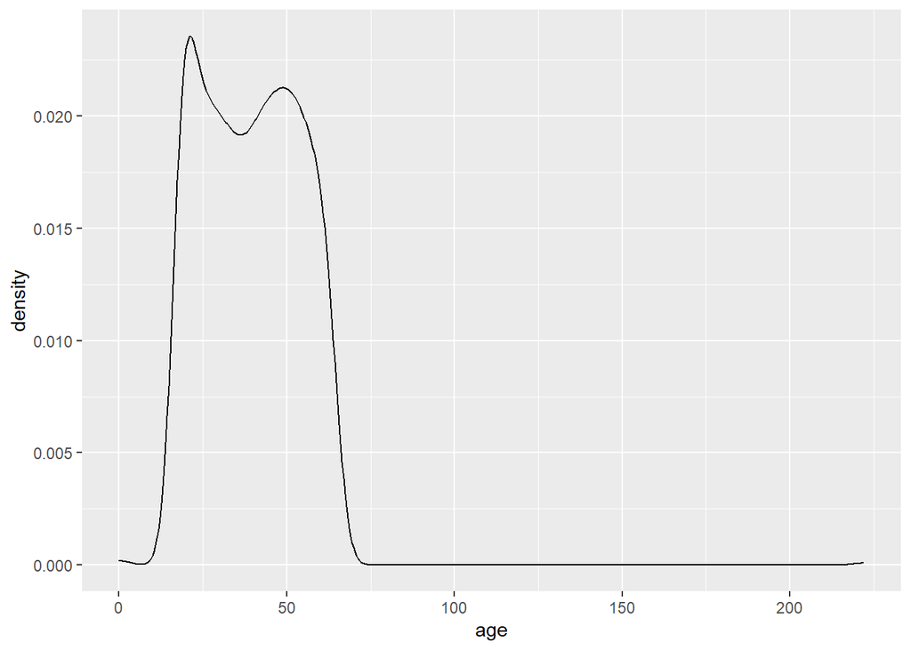

```r
ggplot(insurance_without_na_child_fix_s_s_r, aes(x=age))+
  geom_density()
```

Кажется, что с большинством наблюдений всё в порядке, но это не так очевидно. Попробуем другой график

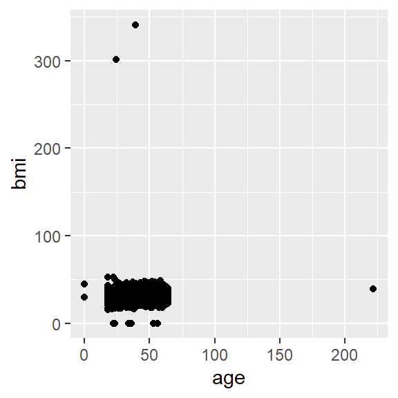

Так стало заметно, что у нас есть несколько очевидных выбросов, давайте отфильтруем их

```r
filter(insurance_without_na_child_fix_s_s_r, bmi>100 | age > 75 )
```

```
##   age    sex   bmi children smoker    region  charges
## 1  24 female 301.0        3     no southwest 4234.927
## 2 222   male  39.5        0     no southwest 1682.597
## 3  39 female 341.0        3     no southwest 7418.522
```

Похоже на опечатку, но лучше удалить

```r
insurance_without_na_child_fix_s_s_r <- filter(insurance_without_na_child_fix_s_s_r, !(bmi>100 | age > 75))
```

### Сложные случаи выбросов

Попробуйте найти:)

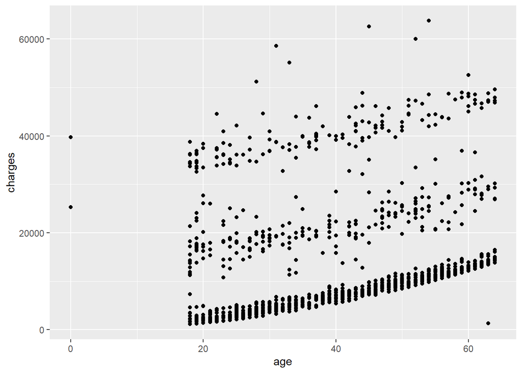

```r
ggplot(insurance_without_na_child_fix_s_s_r, aes(x = age, y=charges))+
  geom_point()
```

Удалим его

```r
filter(insurance_without_na_child_fix_s_s_r, age>60 & charges < 10000)
```

```
##   age  sex  bmi children smoker    region  charges
## 1  63 male 33.1        0     no southwest 1339.756
```

```r
insurance_clean <- filter(insurance_without_na_child_fix_s_s_r, !(age>60 & charges < 10000))
```

Можно упроситить эти поиски

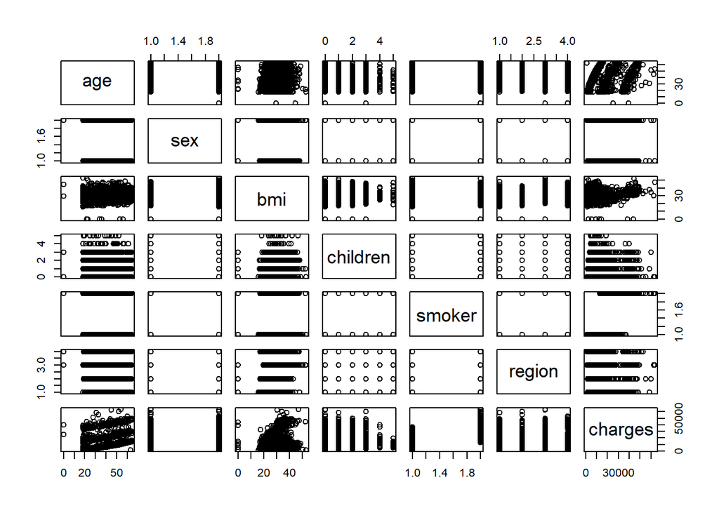

```r
plot(insurance_without_na_child_fix_s_s_r)
```

### Поиск взаимосвязей

Мы почистили данные и можем двигаться дальше. Одна и целей разведочного анализа - выявить связи между переменными. Для описания наших данных можно использовать разные статистики

```r
library(psych)
describe(insurance_clean)
```

```
##          vars    n     mean       sd  median  trimmed     mad     min      max
## age         1 1332    39.17    14.12   39.00    39.00   17.79    0.00    64.00
## sex*        2 1332     1.51     0.50    2.00     1.51    0.00    1.00     2.00
## bmi         3 1332    30.49     6.48   30.30    30.44    6.20    0.00    53.13
## children    4 1332     1.09     1.20    1.00     0.93    1.48    0.00     5.00
## smoker*     5 1332     1.21     0.40    1.00     1.13    0.00    1.00     2.00
## region*     6 1332     2.51     1.10    3.00     2.51    1.48    1.00     4.00
## charges     7 1332 13301.78 12125.63 9401.18 11102.24 7427.29 1121.87 63770.43
##             range  skew kurtosis     se
## age         64.00  0.03    -1.20   0.39
## sex*         1.00 -0.02    -2.00   0.01
## bmi         53.13 -0.25     1.92   0.18
## children     5.00  0.94     0.22   0.03
## smoker*      1.00  1.45     0.12   0.01
## region*      3.00 -0.03    -1.33   0.03
## charges  62648.55  1.51     1.57 332.24
```

Впечатляет, но для факторных переменных не очень подходит, для них расчёты получаются странными. Оставим только числовые переменные

```r
insurance_clean_num <- select(insurance_clean, age, bmi, children, charges)
kable(describe(insurance_clean_num))
```

|  | vars | n | mean | sd | median | trimmed | mad | min | max | range | skew | kurtosis | se |
| --- | --- | --- | --- | --- | --- | --- | --- | --- | --- | --- | --- | --- | --- |
| age | 1 | 1332 | 39.174174 | 14.118358 | 39.0000 | 3.900281e+01 | 17.791200 | 0.000 | 64.00 | 64.00 | 0.0309673 | -1.1962013 | 0.3868406 |
| bmi | 2 | 1332 | 30.491186 | 6.477206 | 30.3025 | 3.043814e+01 | 6.200975 | 0.000 | 53.13 | 53.13 | -0.2450415 | 1.9169736 | 0.1774743 |
| children | 3 | 1332 | 1.091592 | 1.203809 | 1.0000 | 9.324578e-01 | 1.482600 | 0.000 | 5.00 | 5.00 | 0.9446146 | 0.2198027 | 0.0329842 |
| charges | 4 | 1332 | 13301.776283 | 12125.628365 | 9401.1755 | 1.110224e+04 | 7427.292338 | 1121.874 | 63770.43 | 62648.55 | 1.5071743 | 1.5690776 | 332.2401706 |

Мы получили численные описания наших данных, но мы так и не узнали ничего о взаимосвязях между переменными. Простейший способ узнать это базовая функция cor()

```r
cor(insurance_clean_num)
```

```
##                 age         bmi    children    charges
## age      1.00000000 0.103080284 0.041719357 0.29181532
## bmi      0.10308028 1.000000000 0.004784081 0.17330590
## children 0.04171936 0.004784081 1.000000000 0.07015927
## charges  0.29181532 0.173305903 0.070159275 1.00000000
```

Есть более информативный аналог из пакета psych

```r
corr.test(insurance_clean_num)
```

```
## Call:corr.test(x = insurance_clean_num)
## Correlation matrix
##           age  bmi children charges
## age      1.00 0.10     0.04    0.29
## bmi      0.10 1.00     0.00    0.17
## children 0.04 0.00     1.00    0.07
## charges  0.29 0.17     0.07    1.00
## Sample Size
## [1] 1332
## Probability values (Entries above the diagonal are adjusted for multiple tests.)
##           age  bmi children charges
## age      0.00 0.00     0.26    0.00
## bmi      0.00 0.00     0.86    0.00
## children 0.13 0.86     0.00    0.03
## charges  0.00 0.00     0.01    0.00
##
##  To see confidence intervals of the correlations, print with the short=FALSE option
```

age и bmi немного коррелируют с charges

!Но строго говоря, совсем необязательно, что возраст определяет стоимость!

Just for fun! https://rationalnumbers.ru/?go=all/bezumnye-korrelyacii/&ysclid=lcu9eons8p556339890

Пожалуй, лучше всего совместить всё в один график

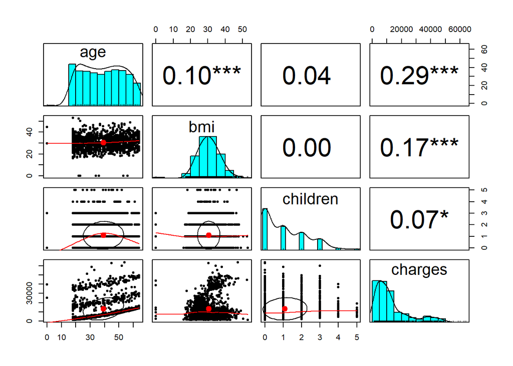

```r
pairs.panels(insurance_clean_num, stars = T)
```

### Категориальные переменные

Сложнее выявить зависимости между категориальными переменными, потому что сложнее заметить тренд. Теперь отберём факторные переменные

table() позволяет нам посчитать число наблюдений для каждой комбинации выбранных факторов

```r
insurance_clean_factor <- select(insurance_clean, -age, -bmi, -children, -charges)
table(insurance_clean_factor$smoker,insurance_clean_factor$sex)
```

```
##
##       female male
##   no     544  514
##   yes    115  159
```

О том как проверить значимость различий мы поговорим на следующей лекции

### Проверка гипотез

Когда мы анализировали наш датасет целиком, smoker и charges показали довльно сильную корреляцию. Давайте проверим гипотезу о том, что цена страховки для курящих отличается от цены для некурящих. Выделим значения для каждой из двух групп, а затем сделаем Т-тест для двух выборок с разными дисперсиями.

```r
smoking <- filter(insurance_clean, smoker == "yes")$charges
nonsmoking <- filter(insurance_clean, smoker == "no")$charges
test_result <- t.test(smoking,nonsmoking)
```

На основании двухстороннего двухвыборочного Т-критерия Уэлча мы можем заключить, что стоимость страховки для курящих и некурящих статистически значимо различается (d.f. = 312.1839104, значение статистики 32.726222, p value 6.3180163^{-103}) при 5% уровне значимости.

### Цитирование

Обычно мы используем много разных библиотек и неплохо бы их было цитировать. Используя команду ниже, можно создать библиографию и затем цитировать пакеты.

```r
knitr::write_bib(c(.packages()), "packages.bib")
```

Xie (2023)

Xie, Yihui. 2023. *Knitr: A General-Purpose Package for Dynamic Report Generation in r*. https://yihui.org/knitr/.